# BMEmapping: An R Package for Spatial Interpolation using Bayesian Maximum Entropy

```r
# posterior mean predictions
BME_mean <- bme_predict(ck, data_object, model, nugget, sill, range,
                        zk_range = c(-3, 4), type = "mean")
head(BME_mean)
```

```
           x        y    mean variance
526 67.90134 91.46572  1.0878   0.8761
527 90.32336 59.91160  0.8695   0.7666
528  2.55267 74.96071  0.3337   0.8489
529 98.90783 91.89547  1.1978   0.8826
530 30.28876 52.87654  0.2696   0.8161
531 93.91384 37.19787 -0.4801   0.8102
```

```r
# posterior median predictions
BME_median <- bme_predict(ck, data_object, model, nugget, sill, range,
                          zk_range = c(-3, 4), type = "median")
head(BME_median)
```

```
           x        y  median
526 67.90134 91.46572  1.0186
527 90.32336 59.91160  0.7984
528  2.55267 74.96071  0.2621
529 98.90783 91.89547  1.1300
530 30.28876 52.87654  0.1980
531 93.91384 37.19787 -0.5564
```

The code below visualizes the spatial distribution of the estimated posterior means alongside their corresponding predictive variances across the mapping domain. An identical plotting configuration can be applied to map the localized posterior mode and median estimates.

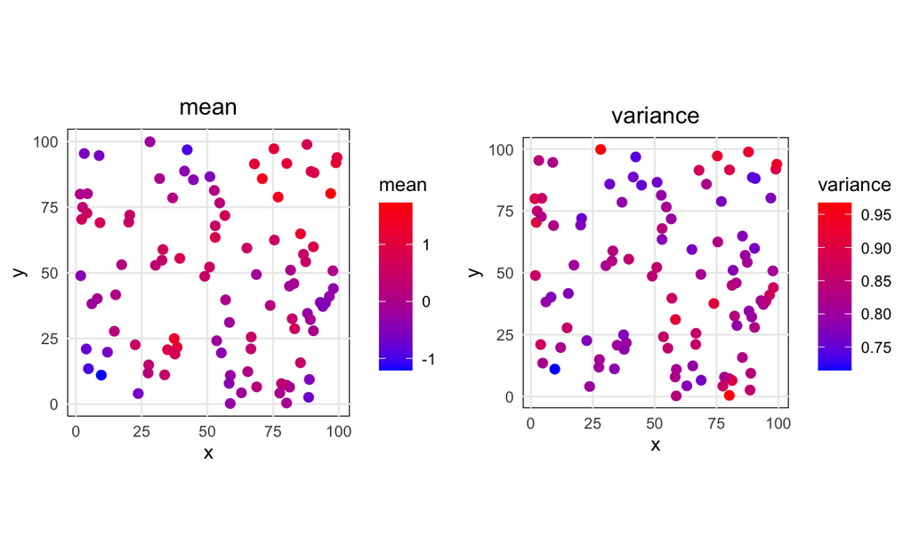

Figure 9: Spatial plots of the posterior mean and variance.

```r
plot(BME_mean)
```

The code below computes the $90\%$ and $95\%$ spatial credible intervals across the target domain; for display purposes, only a subset of these predictive intervals is shown.

```r
# 90% credible interval
bme_predict_ci(head(ck), data_object, model, nugget, sill, range,
               zk_range = c(-3, 5), level = 0.90)
```

```
           x        y lower_90 upper_90
526 67.90134 91.46572  -0.5370   2.5547
527 90.32336 59.91160  -0.6569   2.2285
528  2.55267 74.96071  -1.2680   1.7711
529 98.90783 91.89547  -0.4370   2.6793
530 30.28876 52.87654  -1.3027   1.6786
531 93.91384 37.19787  -2.0504   0.9283
```

```r
# 95% credible interval
bme_predict_ci(head(ck), data_object, model, nugget, sill, range,
               zk_range = c(-3, 5), level = 0.95)
```

```
           x        y lower_95 upper_95
526 67.90134 91.46572  -0.8362   2.8538
527 90.32336 59.91160  -0.9333   2.5095
528  2.55267 74.96071  -1.5554   2.0580
529 98.90783 91.89547  -0.7322   2.9795
530 30.28876 52.87654  -1.5869   1.9644
531 93.91384 37.19787  -2.3233   1.2175
```

Finally, we perform a LOOCV; for display purposes, only a subset of these predictive intervals is shown.

```r
CBME_cv <- bme_cv(data_object, model, nugget, sill, range,
                  zk_range = c(-3, 5), type = "mean", k = nrow(ch))
head(CBME_cv, 10)
```

```
          x        y    observed    mean variance residual fold
1  28.75775 36.44111  2.99784406  1.4072   0.8437   1.5906    1
2  78.83051 27.37513  0.99271757  0.4962   0.8319   0.4965    2
3  40.89769 85.04675  0.29730020 -0.2318   0.7991   0.5291    3
4  88.30174 36.24017 -0.05198823 -0.4328   0.8041   0.3808    4
5  94.04673 30.44778  0.14208672 -0.3829   0.7495   0.5250    5
6   4.55565 75.91353  0.31285805  0.3734   0.8870  -0.0605    6
7  52.81055 84.48346  1.01225916 -0.4093   0.8000   1.4216    7
8  89.24190 45.79216  1.38488300 -0.0695   0.8062   1.4544    8
9  55.14350 72.96317 -0.38279898  0.8742   0.8695  -1.2570    9
10 45.66147 10.40786 -0.06278751  0.4639   0.7974  -0.5267   10
```

A summary of key performance metrics can be generated using the following command.

```r
summary(CBME_cv)
```

```
Summary of BME Cross-Validation
   for hard data locations
--------------------------------
Number of predictions: 125

ME           0.0051
MAE          0.7043
RMSE         0.8845
Rsquared     0.3685
```

The diagnostic plots of the residuals in 10 can be generated using the following command.

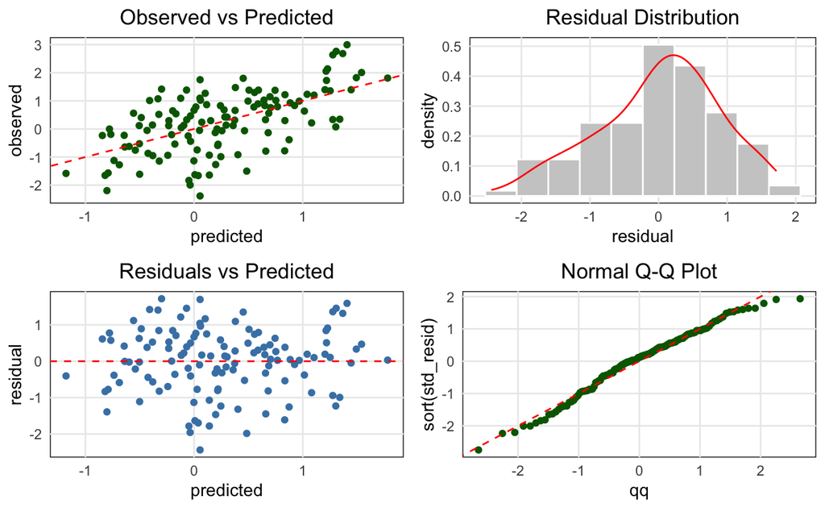

Figure 10: Residual diagnostics for hard data.

```r
plot(CBME_cv)
```

## 5 Conclusion and future directions

The BMEmapping package introduces a rigorous, computationally optimized framework for BME spatial interpolation within the R environment, successfully bridging classical geostatistical structures with general probabilistic information processing. By seamlessly integrating exact physical measurements (hard data) alongside bounded, interval-valued constraints (soft data), the package circumvents the structural Gaussian and linearity limitations inherent to traditional kriging methodologies.

Throughout this paper, we demonstrated comprehensive operational workflows for both the CBME and QBME frameworks. These pipelines span empirical semivariogram estimation, localized posterior probability density derivation, non-Gaussian uncertainty propagation, and automated cross-validation diagnostics. Using spatial data applications, we illustrated how explicitly accounting for interval uncertainty yields highly nuanced spatial predictions. This approach provides distinct posterior mean, median, and mode estimators alongside robust spatial variance fields and asymmetric credible intervals that adapt organically to localized data configurations.

The current implementation proves uniquely suited for environmental, hydrological, and meteorological applications where physical monitoring networks are inherently heterogeneous, sparse, or subject to sensor detection thresholds.

### 5.1 Future methodological improvements

While the accelerated interval-valued routines within BMEmapping provide a scalable foundation for practical geostatistics, several foundational expansions are planned for future iterations to fully leverage the theoretical capabilities of the BME paradigm:

- **Probabilistic soft data integration**: Future releases will expand the soft data ingestion pipeline beyond bounded intervals to accommodate continuous probabilistic distributions. This includes Gaussian soft data defined by a localized mean $\mu$ and standard error $\sigma$ derived from collocated proxy variables or remote sensing instruments, as well as arbitrary, custom non-parametric probability density functions (PDFs).
- **Functional and categorical soft constraints**: Methodological work is underway to support soft data formatted as continuous functions or conditional probability matrices. This advancement will allow users to pass complex soft information, such as categorical indicator probabilities, non-parametric risk curves, or physics-informed boundary constraints, directly into the core entropy maximization engine.
- **Spatiotemporal extensions**: Expanding the underlying spatial covariance architectures into the space-time domain will enable the package to model dynamic environmental systems, capturing concurrent spatial correlation structures and temporal dependencies.
- **Uncertainty quantification and calibration metrics**: Future versions will incorporate additional diagnostics for evaluating predictive uncertainty, including coverage probability measures based on posterior credible intervals. Metrics such as 95% coverage probability will provide a quantitative assessment of whether the estimated uncertainty intervals are properly calibrated and whether the nominal confidence levels align with observed prediction performance. These additions will complement existing point prediction accuracy measures and provide users with a more comprehensive framework for evaluating both predictive accuracy and uncertainty reliability.

Although some of these advanced extensions will eliminate the current closed-form analytical simplifications and necessitate the deployment of computationally intensive stochastic methods such as Markov chain Monte Carlo (MCMC) sampling, the modular architecture of the package is explicitly designed to readily support and accommodate these future algorithmic enhancements.

### 5.2 Supplementary materials

Supplementary materials are available in addition to this article. It can be downloaded at RJ-2026-057.zip

### 5.3 CRAN packages used

BMEmapping, gstat, fields, spmodel, intkrige, devtools

### 5.4 CRAN Task Views implied by cited packages

MixedModels, Spatial, SpatioTemporal

S. Banerjee, B. P. Carlin and A. E. Gelfand. *Hierarchical modeling and analysis for spatial data.* 2nd ed Boca Raton, FL: CRC Press, 2014. DOI https://doi.org/10.1201/b17115.

B. L. Bean, M. Maguire, Y. Sun, J. Wagstaff, S. Al-Rubaye, J. Wheeler, S. Jarman and M. Rogers. The 2020 national snow load study. *Mathematics and Statistics Faculty Publications. Paper 276*, 1–177, 2021. DOI https://doi.org/10.26077/200k-pr86.

B. Bean, Y. Sun and M. Maguire. Interval-valued kriging for geostatistical mapping with imprecise inputs. *Int. J. Approx. Reason.*, 140: 31–51, 2022. DOI https://doi.org/10.1016/j.ijar.2021.10.003.

J. S. Becker, M. N. DeLang, K.-L. Chang, M. L. Serre, O. R. Cooper, H. Wang, M. G. Schultz, S. Schroder, X. Lu, L. Zhang, et al. Using regionalized air quality model performance and bayesian maximum entropy data fusion to map global surface ozone concentration. *Elementa: Science of the Anthropocene*, 11(1): 00025, 2023. DOI https://doi.org/10.1525/elementa.2022.00025.

P. Bogaert and G. Christakos. Spatiotemporal analysis and processing of thermometric data over belgium. *Journal of Geophysical Research - Atmospheres*, 102(D22): 25831–25846, 1997. DOI https://doi.org/10.1029/97JD01809.

J.-P. Chilès and P. Delfiner. *Geostatistics: Modeling spatial uncertainty.* 2nd ed Hoboken, NJ: John Wiley & Sons, 2012. DOI https://doi.org/10.1002/9781118136188.

G. Christakos. A bayesian/maximum-entropy view to the spatial estimation problem. *Mathematical Geology*, 22: 763–777, 1990. DOI https://doi.org/10.1007/BF00890661.

G. Christakos. *Modern spatiotemporal geostatistics.* Oxford university press, 2000. DOI https://doi.org/10.1023/A:1021154113388.

G. Christakos and H. T. Dionissios. Environmental health modelling: A tractatus stochasticus. 1998. DOI https://doi.org/10.1007/978-1-4757-2811-8.

G. Christakos and X. Li. Bayesian maximum entropy analysis and mapping: A farewell to kriging estimators? *Mathematical Geology*, 30: 435–462, 1998. DOI https://doi.org/10.1023/A:1021748324917.

G. Christakos and M. L. Serre. BME analysis of spatiotemporal particulate matter distributions in north carolina. *Atmospheric Environment*, 34(20): 3393–3406, 2000. DOI https://doi.org/10.1016/S1352-2310(00)00080-7.

N. A. C. Cressie. *Statistics for spatial data.* Revised New York: John Wiley & Sons, 1993. DOI https://doi.org/10.1002/9781119115151.

P. Diamond. Interval-valued random functions and the kriging of intervals. *Math. Geol.*, 20: 145–165, 1988. DOI https://doi.org/10.1007/BF00890251.

A. Douaik, M. Van Meirvenne and T. Tóth. Soil salinity mapping using spatio-temporal kriging and bayesian maximum entropy with interval soft data. *Geoderma*, 128(3-4): 234–248, 2005. DOI https://doi.org/10.1016/j.geoderma.2005.04.006.

P. Dowd. A review of recent developments in geostatistics. *Computers & Geosciences*, 17(10): 1481–1500, 1991. DOI https://doi.org/10.1016/0098-3004(91)90009-3.

K. Duah, Y. Sun and B. Bean. Integrating multi-source geospatial information using bayesian maximum entropy: A case study on design ground snow load prediction. *Spatial Statistics*, 100894, 2025. DOI https://doi.org/10.1016/j.spasta.2025.100894.

K. Duah, Y. Sun and M. Moussa. A random quantile approach for prior covariance estimation in bayesian maximum entropy. *Spatial Statistics*, 100974, 2026. DOI https://doi.org/10.1016/j.spasta.2026.100974.

D. Fu, Z. Song, X. Zhang, X. Xia, J. Wang, H. Che, H. Wu, X. Tang, J. Zhang and M. Duan. Mitigating MODIS AOD non-random sampling error on surface PM2. 5 estimates by a combined use of bayesian maximum entropy method and linear mixed-effects model. *Atmospheric Pollution Research*, 11(3): 482–490, 2020. DOI https://doi.org/10.1016/j.apr.2019.11.020.

A. K. Jain. *Fundamentals of digital image processing.* Prentice-Hall, Inc., 1989. URL https://dl.acm.org/doi/book/10.5555/59921.

A. G. Journel. Constrained interpolation and qualitative information-the soft kriging approach. *Mathematical Geology*, 18: 269–286, 1986. DOI https://doi.org/10.1007/BF00898032.

A. G. Journel and A. G. Journel. *Fundamentals of geostatistics in five lessons.* American Geophysical Union Washington, DC, 1989. DOI https://doi.org/10.1029/SC008.

A. R. Olea. A six-step practical approach to semivariogram modeling. *Stochastic Environmental Research and Risk Assessment*, 20(5): 307–318, 2006. DOI https://doi.org/10.1007/s00477-005-0026-1.

J. E. Pebesma. Multivariable geostatistics in s: The gstat package. *Computers & Geosciences*, 30(7): 683–691, 2004. DOI https://doi.org/10.1016/j.cageo.2004.03.012.

R Core Team. *R: A language and environment for statistical computing.* Vienna, Austria: R Foundation for Statistical Computing, 2016. URL https://www.R-project.org/. ISBN 3-900051-07-0.

M. L. Serre. *Environmental spatiotemporal mapping and groundwater flow modelling using the BME and ST methods.* The University of North Carolina at Chapel Hill, 1999. URL https://mserre.sph.unc.edu/docFile/MarcSerre_WholeDissertation.pdf.

M. L. Serre and G. Christakos. Modern geostatistics: Computational BME analysis in the light of uncertain physical knowledge–the equus beds study. *Stochastic Environmental Research and Risk Assessment*, 13: 1–26, 1999. DOI https://doi.org/10.1007/s004770050029.

Q. Tang, Y. Bo and Y. Zhu. Spatiotemporal fusion of multiple-satellite aerosol optical depth (AOD) products using bayesian maximum entropy method. *Journal of Geophysical Research: Atmospheres*, 121(8): 4034–4048, 2016. DOI https://doi.org/10.1002/2015JD024571.

H. Wackernagel. *Multivariate geostatistics: An introduction with applications.* 3rd ed Berlin: Springer, 2003. DOI https://doi.org/10.1007/978-3-662-05294-5.

R. Webster and M. A. Oliver. *Geostatistics for environmental scientists.* 2nd ed Chichester, UK: John Wiley & Sons, 2007. DOI https://doi.org/10.1002/9780470517277.

H. Wickham, J. Hester, W. Chang and J. Bryan. Devtools: Tools to make developing r packages easier. 2022. URL https://CRAN.R-project.org/package=devtools. R package version 2.4.5.

S. Xu, C. Cui, M. Shan, Y. Liu, Z. Qiao, L. Chen, Z. Ma, H. Zhang, S. Gao and Y. Sun. Spatio-temporal prediction of ground-level ozone concentration based on bayesian maximum entropy by combining monitoring and satellite data. *Atmosphere*, 13(10): 1568, 2022. DOI https://doi.org/10.3390/atmos13101568.

Ö. B. Yeşilköy. Estimation of PM10 concentrations in turkey based on bayesian maximum entropy. *International Advanced Researches and Engineering Journal*, 4(1): 48–55, 2020. DOI https://doi.org/10.35860/iarej.672520.